# Algorithms in Detail

- Imports
- Data Pre-processing
- Linear Regression
- Logistic Regression
- K Nearest Neighbour
- Niave Bayes
- Decision Tree
- Neural Network
- Deep Learning

## Imports

```python
import numpy as np
import pandas as pd
import matplotlib.pyplot as plt
plt.rcParams["figure.figsize"] = (10,10)
from sklearn import preprocessing
import math

from sklearn.linear_model import LinearRegression
from sklearn.linear_model import LogisticRegression
from sklearn.tree import DecisionTreeClassifier
from sklearn import tree
from sklearn.neighbors import KNeighborsClassifier
from sklearn.naive_bayes import GaussianNB

import tensorflow as tf
from tensorflow import keras
from tensorflow.keras.models import Sequential
from tensorflow.keras.layers import Dense
```

## Data Pre-processing

```
Raw Data

      outlook  temp humidity    wind play
0      Sunny   Hot     High    Weak   No
1      Sunny   Hot     High  Strong   No
2   Overcast   Hot     High    Weak  Yes
3       Rain  Mild     High    Weak  Yes
4       Rain  Cool   Normal    Weak  Yes
5       Rain  Cool   Normal  Strong   No
6   Overcast  Cool   Normal  Strong  Yes
7      Sunny  Mild     High    Weak   No
8      Sunny  Cool   Normal    Weak  Yes
9       Rain  Mild   Normal    Weak  Yes
10     Sunny  Mild   Normal  Strong  Yes
11  Overcast  Mild     High  Strong  Yes
12  Overcast   Hot   Normal    Weak  Yes
13      Rain  Mild     High  Strong   No
         outlook       temp   humidity       wind       play
count  14.000000  14.000000  14.000000  14.000000  14.000000
mean    1.071429   1.142857   0.500000   0.571429   0.642857
std     0.828742   0.864438   0.518875   0.513553   0.497245
min     0.000000   0.000000   0.000000   0.000000   0.000000
25%     0.250000   0.250000   0.000000   0.000000   0.000000
50%     1.000000   1.000000   0.500000   1.000000   1.000000
75%     2.000000   2.000000   1.000000   1.000000   1.000000
max     2.000000   2.000000   1.000000   1.000000   1.000000


Preprocessed Data

     outlook  temp  humidity  wind  play
0         2     1         0     1     0
1         2     1         0     0     0
2         0     1         0     1     1
3         1     2         0     1     1
4         1     0         1     1     1
5         1     0         1     0     0
6         0     0         1     0     1
7         2     2         0     1     0
8         2     0         1     1     1
9         1     2         1     1     1
10        2     2         1     0     1
11        0     2         0     0     1
12        0     1         1     1     1
13        1     2         0     0     0
```

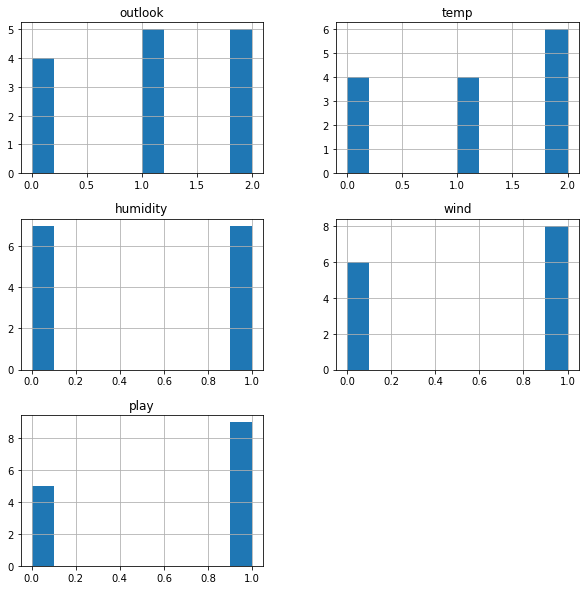

```python
data = pd.read_csv("weather.csv")

print("\n\nRaw Data\n\n",data)



data = data.apply(preprocessing.LabelEncoder().fit_transform)
data.hist()
print(data.describe())
"""
# per column in case some are some are not categorical

labelencoder = preprocessing.LabelEncoder()
data["outlook"] = labelencoder.fit_transform(data["outlook"])
data["temp"] = labelencoder.fit_transform(data["temp"])
data["humidity"] = labelencoder.fit_transform(data["humidity"])
data["wind"] = labelencoder.fit_transform(data["wind"])
data["play"] = labelencoder.fit_transform(data["play"])
"""

print("\n\nPreprocessed Data\n\n",data)

array = data.values
attributes = array[:,0:4]
classValues = array[:,4]
```

## Linear Regression

```python
model = LinearRegression()

model.fit(attributes,classValues)

results = model.score(attributes,classValues)


# That is trained, lets make some predictions!
print()
unsceen1 = [[2,1,0,1]]
result1 = model.predict(unsceen1)
print(result1[0])

print()
unsceen2 = [[0,1,0,1]]
result2 = model.predict(unsceen2)
print(result2[0])


# for humans using the method from Andrew NG converting it to a classification algorithm!
print()
print()
if result1[0] < 0.5:
    print("Do not play")
else:
    print("Play")


if result2[0] < 0.5:
    print("Do not play")
else:
    print("Play")
```

```
0.20699486789583743

0.7996578597224863


Do not play
Play
```

### Linear Regression in more detail:

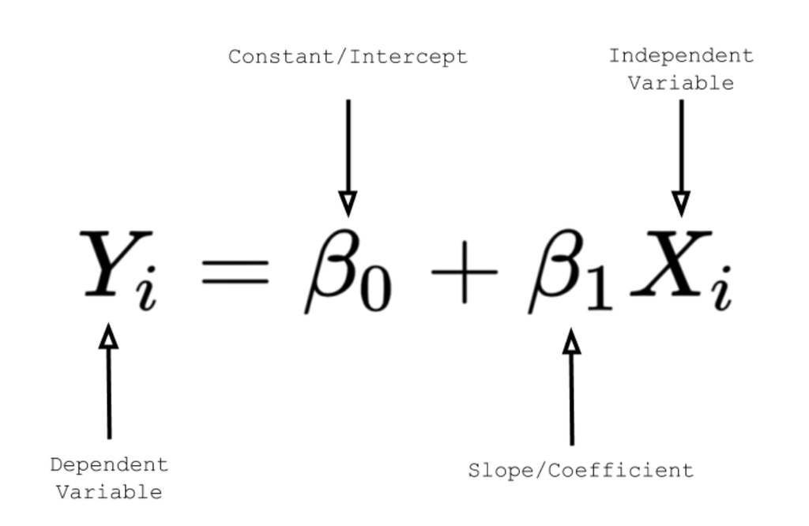

```python
from IPython.display import Image
Image("lr.png", width = 600, height = 300)
```

### Linear Regresison Learning

A cost function determines how much error exists in a model. This allows us to then adjust the parameters (Intercept and Coefficient).

In Linear Regression, Mean Squared Error (MSE) cost function is used, which is the average of squared error that occurred between the predicted values and actual values.

By simple linear equation y=mx+b we can calculate MSE as (Where: y = actual values, yi = predicted values):

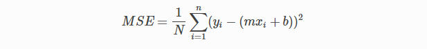

```python
from IPython.display import Image
Image("mse.png", width = 900, height = 450)
```

If the intercept and coefficient values were randomly/iteratively adjusted, this would take significant time (if even possible), thus the solution is a technique called Gradient Descent.

```python
from IPython.display import Image
Image("gradientDescent.jpg", width = 900, height = 450)
```

[output not shown]

### Linear Regression - Once Trained

- Each independant attribute has an equation
- Each has the same intercept
- This is called multiple regression

```
Performance (R squared): 0.5532

Intercept: 0.34214027751378084
Slope    : [-0.2963315   0.1636571   0.52651587  0.29386048]

Attribute 1: y = 0.34 + -0.3x
Attribute 2: y = 0.34 + 0.16x
Attribute 3: y = 0.34 + 0.53x
Attribute 4: y = 0.34 + 0.29x
```

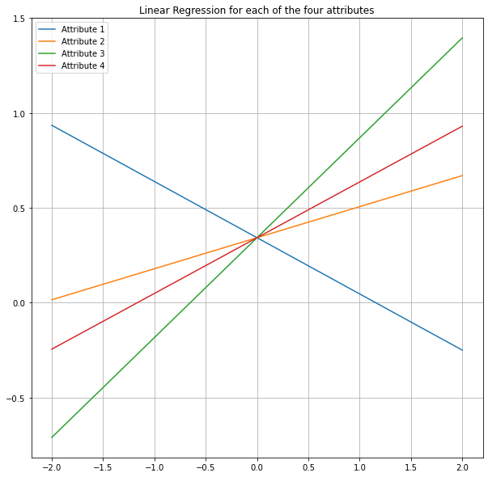

```python
print("Performance (R squared):" , round(results,4))
print()

# LR Intercept (C)
print("Intercept:", model.intercept_)

# LR Slope (M) one for each parameter
print("Slope    :", model.coef_)

print()

print("Attribute 1: y =", round(model.intercept_,2),"+", str(round(model.coef_[0],2))+"x")
print("Attribute 2: y =", round(model.intercept_,2),"+", str(round(model.coef_[1],2))+"x")
print("Attribute 3: y =", round(model.intercept_,2),"+", str(round(model.coef_[2],2))+"x")
print("Attribute 4: y =", round(model.intercept_,2),"+", str(round(model.coef_[3],2))+"x")

# Plotting each line:
att = 1
x = np.linspace(-2,2,100)

plt.title("Linear Regression for each of the four attributes")
for coef in model.coef_:
    y = coef*x+model.intercept_
    name = "Attribute " + str(att)
    plt.plot(x, y, label=name)
    att += 1
plt.grid()
plt.legend()
plt.show()
```

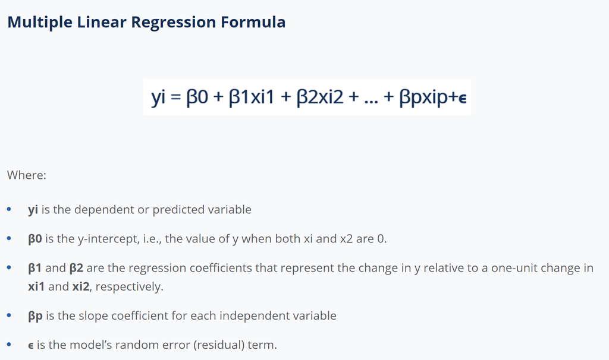

```python
from IPython.display import Image
Image("multipleLR.png", width = 800, height = 300)
```

```python
# Model prediction
unsceen1 = [[2,1,0,1]]
result1 = model.predict(unsceen1)
print("y - Model generated:\t", result1[0])

# Manual creation of prediction
unsceenM = [2,1,0,1]
y = model.intercept_ +  (model.coef_[0]*unsceenM[0]) + \
                        (model.coef_[1]*unsceenM[1]) + \
                        (model.coef_[2]*unsceenM[2]) + \
                        (model.coef_[3]*unsceenM[3])
print("y - Manually generated:\t", y)
```

```
y - Model generated:	 0.20699486789583743
y - Manually generated:	 0.20699486789583743
```

## Logistic Regression

```python
model = LogisticRegression()

model.fit(attributes,classValues)

results = model.score(attributes,classValues)


print()
unsceen1 = [[2,1,0,1]]
result1 = model.predict(unsceen1)
print(result1[0])

print()
unsceen2 = [[0,1,0,1]]
result2 = model.predict(unsceen2)
print(result2[0])


# for humans!
print()
print()
if result1[0] == 0:
    print("Do not play")
else:
    print("Play")


if result2[0] == 0:
    print("Do not play")
else:
    print("Play")
```

```
0

1


Do not play
Play
```

### Logistic Regression in more detail:

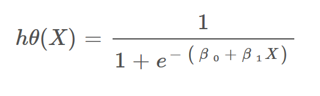

```python
from IPython.display import Image
Image("logR.png")
```

### Logistic Regresison Learning

Just like in Linear Regression, the cost function determines how much error exists in a model. This allows us to then adjust the parameters (Intercept and Coefficient).

In Logistic Regression, it can not use the MSE cost function as Logistic Regression is non-linear (even though the final curve is often treated as linear).

The loss function is:

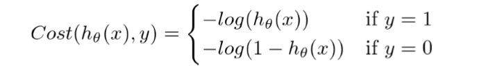

```python
from IPython.display import Image
Image("logRCost.png", width = 900, height = 450)
```

Where the above two functions can be combined into one function:

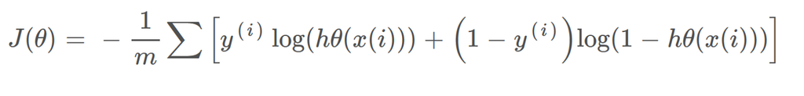

```python
from IPython.display import Image
Image("logRCostCombined.png", width = 900, height = 450)
```

Just like in Linear Regression, ff the intercept and coefficient values were randomly/iteratively adjusted, this would take significant time (if even possible), thus the solution is a technique called Gradient Descent.

```python
from IPython.display import Image
Image("gradientDescent.jpg", width = 900, height = 450)
```

[output not shown]

### Logistic Regression - Once Trained

- Each independant attribute has an equation
- Each has the same intercept
- This is called multiple regression

```
Accuracy: 85.7143 %
Intercept Bo  : 0.7517973741355707
Coef B1       : [-0.92609992  0.14751136  0.87410894  0.56955225]

Attribute 1: h0(x) = 1 / 1 + e-( 0.75 + -0.93x)
Attribute 2: h0(x) = 1 / 1 + e-( 0.75 + 0.15x)
Attribute 3: h0(x) = 1 / 1 + e-( 0.75 + 0.87x)
Attribute 4: h0(x) = 1 / 1 + e-( 0.75 + 0.57x)
```

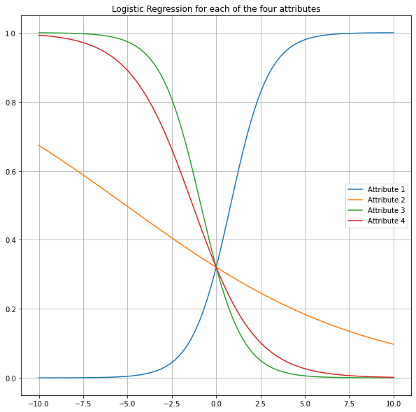

```python
print("Accuracy:", round(results *100,4), "%")

# intercept Bo
print("Intercept Bo  :", model.intercept_[0])

# Coef one for each parameter
print("Coef B1       :", model.coef_[0])

print()

print("Attribute 1: h0(x) =", "1 / 1 + e-(",round(model.intercept_[0],2),"+", str(round(model.coef_[0][0],2))+"x)")
print("Attribute 2: h0(x) =", "1 / 1 + e-(",round(model.intercept_[0],2),"+", str(round(model.coef_[0][1],2))+"x)")
print("Attribute 3: h0(x) =", "1 / 1 + e-(",round(model.intercept_[0],2),"+", str(round(model.coef_[0][2],2))+"x)")
print("Attribute 4: h0(x) =", "1 / 1 + e-(",round(model.intercept_[0],2),"+", str(round(model.coef_[0][3],2))+"x)")


# Plotting each line:
att = 1
x = np.linspace(-10,10,100)

plt.title("Logistic Regression for each of the four attributes")
for coef in model.coef_[0]:
    y = 1 / (1 + np.exp((coef*x)+model.intercept_))
    name = "Attribute " + str(att)
    plt.plot(x, y, label=name)
    att += 1
plt.grid()
plt.legend()
plt.show()
```

```python
print()
unsceen1 = [[2,1,0,1]]
result1 = model.predict_proba(unsceen1)
print("SKLearn:  ", result1[0])

#manual
unsceenM = [2,1,0,1]
y = 1 / (1 + math.exp(model.intercept_[0] + (model.coef_[0][0]*unsceenM[0]) + (model.coef_[0][1]*unsceenM[1]) + (model.coef_[0][2]*unsceenM[2]) + (model.coef_[0][3]*unsceenM[3])          ))
print("Manual :   [" +str(round(y,8)) +" "+ str(round(1-y,8)) +"]")
```

```
SKLearn:   [0.59467814 0.40532186]
Manual :   [0.59467814 0.40532186]
```

## K Nearest Neighbour

p : int, default=2  
Power parameter for the Minkowski metric.

- When p = 1, this is equivalent to using manhattan_distance
- When p = 2, this is equivalent to using euclidean_distance

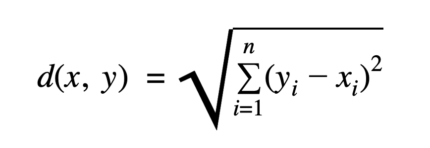

```python
from IPython.display import Image
Image("eclud.png")
```

```python
model = KNeighborsClassifier(n_neighbors=3, p = 2)

model.fit(attributes,classValues)

results = model.score(attributes,classValues)


print()
unsceen1 = [[2,1,0,1]]
result1 = model.predict(unsceen1)
print(result1[0])

print()
unsceen2 = [[0,1,0,1]]
result2 = model.predict(unsceen2)
print(result2[0])


# for humans!
print()
print()
if result1[0] == 0:
    print("Do not play")
else:
    print("Play")


if result2[0] == 0:
    print("Do not play")
else:
    print("Play")
```

```
0

1


Do not play
Play
```

### Retreiving the nearest neighbours and their indices

```python
distances, indices = model.kneighbors(unsceen1)
print("Nearest Three Distances")
print(distances)
print("\nIndices of top Three")
print(indices)
```

```
Nearest Three Distances
[[0. 1. 1.]]

Indices of top Three
[[0 7 1]]
```

### Elbow Method for Selection of K:

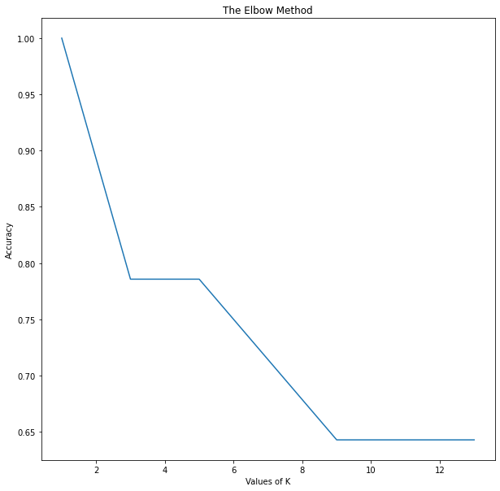

```python
# elbow method
accValues = []
for k in range(1,len(attributes),2):
    model = KNeighborsClassifier(n_neighbors=k)
    model.fit(attributes, classValues)
    results = model.score(attributes, classValues)
    accValues.append(results.mean())

plt.plot(list(range(1,len(attributes),2)),accValues)
plt.xlabel('Values of K')
plt.ylabel('Accuracy')
plt.title('The Elbow Method')
plt.show()
```

## Nieve Bayes

```python
model = GaussianNB()

model.fit(attributes,classValues)

results = model.score(attributes,classValues)


print()
unsceen1 = [[2,1,0,1]]
result1 = model.predict(unsceen1)
print(result1[0])

print()
unsceen2 = [[0,1,0,1]]
result2 = model.predict(unsceen2)
print(result2[0])


# for humans!
print()
print()
if result1[0] == 0:
    print("Do not play")
else:
    print("Play")


if result2[0] == 0:
    print("Do not play")
else:
    print("Play")
```

```
0

1


Do not play
Play
```

### naive Bayes in more detail:

Naive Bayes is a probalistic classifier

Naïve Bayes is a non-parametric probabilistic model based on an assumption of conditional independence among variable attributes. Although this assumption is often violated, naïve Bayes classifiers have been shown to work surprisingly well and have highly competitive prediction performance even when compared with some state-of-the art classifiers.

The following formula represents naive bayes, where the c = class that you are calculating for the probability of (note, in SKLEARN, you are returned the proabilities of both classes using: model.predict_proba), x is the probability of that attribute value resulting in a class label.

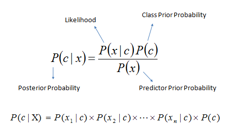

```python
from IPython.display import Image
Image("Bayes_rule.png")
```

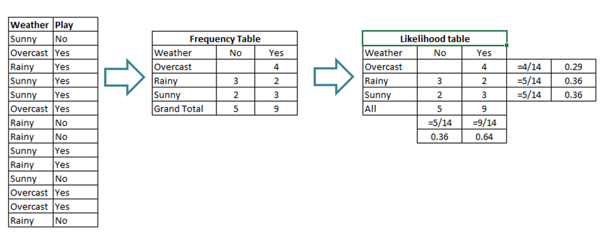

```python
from IPython.display import Image
Image("nb1.png")
```

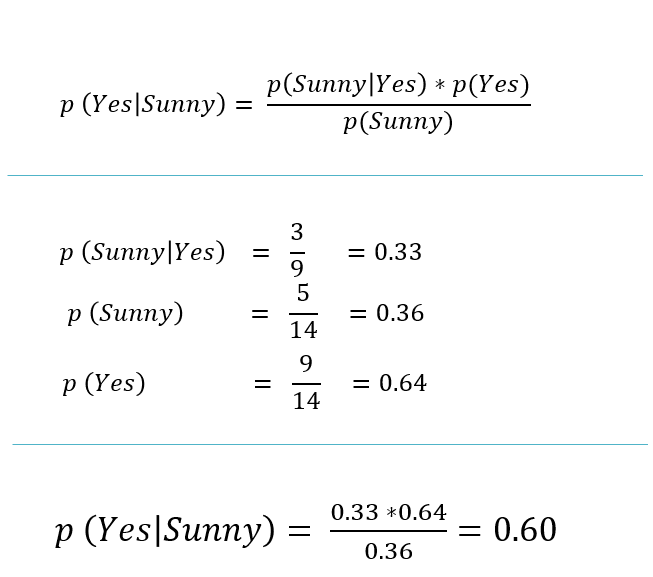

```python
from IPython.display import Image
Image("nb2.png")
```

### Naive Bayes Multiclass

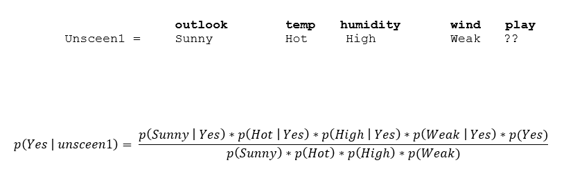

```python
from IPython.display import Image
Image("nb4.png")
```

### Both class values probabilities

```python
print("Unsceen 1\n")
prob = model.predict_proba(unsceen1)
# returns the prob for each class [0, 1]
print("Predicted prob class 0:",  prob[0][0])
print("Predicted prob class 1:",  prob[0][1])

print("\n\nUnsceen 2\n")
prob = model.predict_proba(unsceen2)
# returns the prob for each class [0, 1]
print("Predicted prob class 0:",  prob[0][0])
print("Predicted prob class 1:",  prob[0][1])
```

```
Unsceen 1

Predicted prob class 0: 0.8006878062741724
Predicted prob class 1: 0.19931219372582767


Unsceen 2

Predicted prob class 0: 0.013004098926338511
Predicted prob class 1: 0.9869959010736614
```

## Decision Tree

```python
model = DecisionTreeClassifier()

model.fit(attributes,classValues)

results = model.score(attributes,classValues)


print()
unsceen1 = [[2,1,0,1]]
result1 = model.predict(unsceen1)
print(result1[0])

print()
unsceen2 = [[0,1,0,1]]
result2 = model.predict(unsceen2)
print(result2[0])


# for humans!
print()
print()
if result1[0] < 0.5:
    print("Do not play")
else:
    print("Play")


if result2[0] < 0.5:
    print("Do not play")
else:
    print("Play")
```

```
0

1


Do not play
Play
```

### Decision Trees in more detail:

Decision Trees use (typically) the CART algorithm to split the nodes based on each nodes impurity (the lack of homogeneity for a class value - where 1 is the lowest homogeneity and 0 being teh highest - all one class value).

Cart ues Gini impurity, and only works for classification problems. Gini is used over entropy as it does not include a log fucntion (less computationally intensive).

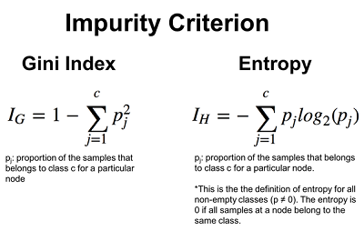

```python
from IPython.display import Image
Image("gE.png")
```

Where:

```python
from IPython.display import Image
Image("dt2.png")
```

[output not shown]

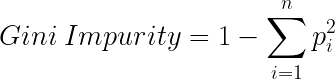

```python
from IPython.display import Image
Image("dt3.png")
```

### Splitting the tree

- For each split in the attribute values individually calculate the Gini Impurity attribute value to the class value
- Calculate the Gini Impurity of each split as the weighted average Gini Impurity of child nodes
- Select the split with the lowest value of Gini Impurity
- Interatively repeat until you achieve homogeneous nodes only

#### Example using the first two nodes:

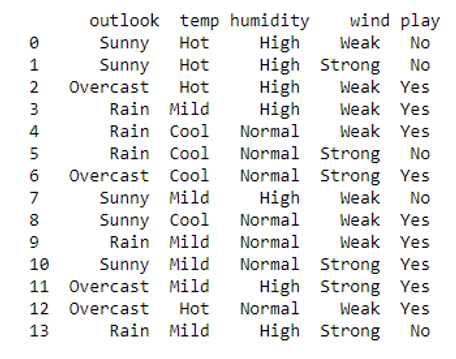

```python
from IPython.display import Image
Image("dt4.png")
```

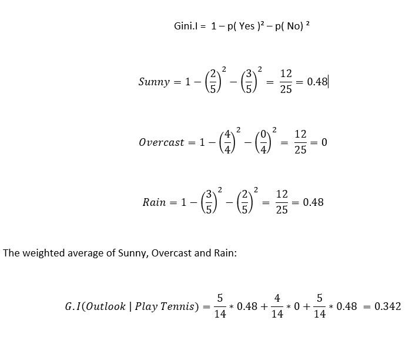

```python
from IPython.display import Image
Image("dt5.png")
```

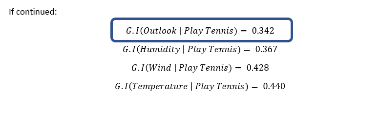

```python
from IPython.display import Image
Image("dt6.png")
```

#### Repeating

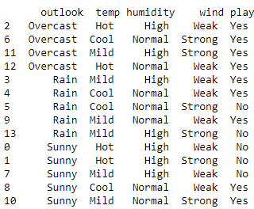

```python
from IPython.display import Image
Image("dt7.png")
```

Now that we have three nodes/branches for the root node, we sort by branch and complete the process again until we achieve homogeneous nodes only. In the typical Decision Tree example using the play tennis dataset, it actually leaves out the Temperature attribute.

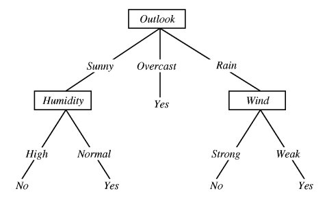

```python
from IPython.display import Image
Image("dt8.jpg")
```

#### Please note:

SKLEARN's is developed to only work with numerical attributes, and somewhat disguises categorogical features using (what we did - label encorders). Thus the algorithm employs a binary tree approach (ignoring our theoritical example above using Gini), as it is more difficult to identify more that two ranges in a numerical range.

Below we have the output for the Play Tennis dataset, with the Gini's are different, due to the binary tree approach.

```python
print("Accuracy:", round(results *100,4), "%\n\n")

# Visualise the tree
text_representation = tree.export_text(model)
print(text_representation)
```

```
Accuracy: 100.0 %


|--- feature_0 <= 0.50
|   |--- class: 1
|--- feature_0 >  0.50
|   |--- feature_2 <= 0.50
|   |   |--- feature_0 <= 1.50
|   |   |   |--- feature_3 <= 0.50
|   |   |   |   |--- class: 0
|   |   |   |--- feature_3 >  0.50
|   |   |   |   |--- class: 1
|   |   |--- feature_0 >  1.50
|   |   |   |--- class: 0
|   |--- feature_2 >  0.50
|   |   |--- feature_3 <= 0.50
|   |   |   |--- feature_1 <= 1.00
|   |   |   |   |--- class: 0
|   |   |   |--- feature_1 >  1.00
|   |   |   |   |--- class: 1
|   |   |--- feature_3 >  0.50
|   |   |   |--- class: 1
```

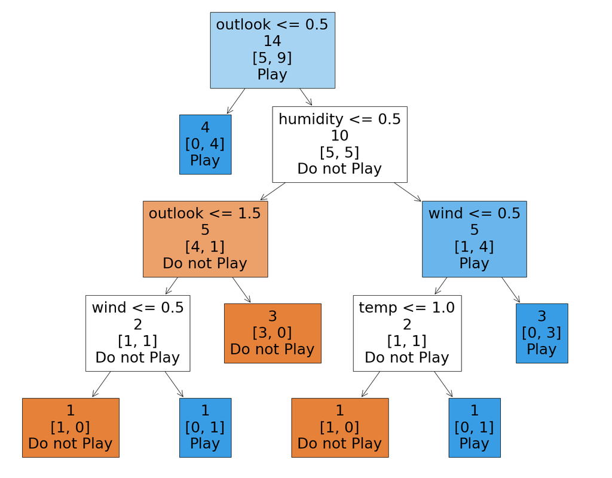

```python
colNames = data.columns.tolist()

fig = plt.figure(figsize=(25,20))
_ = tree.plot_tree(model,
                   feature_names=colNames[0:4],
                   class_names=["Do not Play", "Play"],
                   filled=True,
                   impurity=False, label=None)
```

## Neural Network

```
Train on 14 samples
```

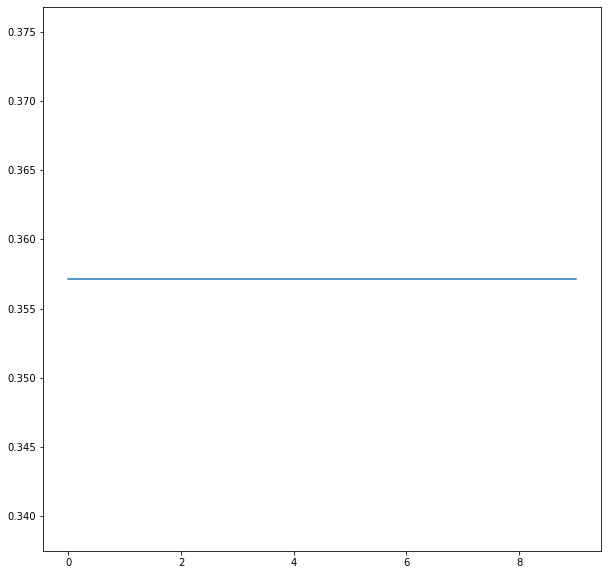

```
Model: "sequential"
_________________________________________________________________
Layer (type)                 Output Shape              Param #
=================================================================
dense (Dense)                (None, 3)                 15
_________________________________________________________________
dense_1 (Dense)              (None, 1)                 4
=================================================================
Total params: 19
Trainable params: 19
Non-trainable params: 0
_________________________________________________________________
None

[0.43733388]

[0.45620897]


Do not play
Do not play
```

```python
# fix random seed for reproducibility
seed = 1
np.random.seed(seed)
tf.random.set_seed(seed)


model = Sequential()
model.add(Dense(3, input_dim=4, activation='sigmoid'))
model.add(Dense(1, activation='sigmoid'))
model.compile(loss='mean_absolute_error', optimizer='sgd',metrics=['acc'])           # Note not correct loss function

results = model.fit(attributes, classValues, epochs=10)

plt.plot(results.history["acc"])
plt.show()

print(model.summary())



print()
unsceen1 = [[2,1,0,1]]
result1 = model.predict(unsceen1)
print(result1[0])

print()
unsceen2 = [[0,1,0,1]]
result2 = model.predict(unsceen2)
print(result2[0])


# for humans!
print()
print()
if result1[0] < 0.5:
    print("Do not play")
else:
    print("Play")


if result2[0] < 0.5:
    print("Do not play")
else:
    print("Play")
```

### Artificial neural networks in more detail:

Neural networks are built of multipe perceptrons, that in essence were developed to mimick (to the most basic sense) a human neuron. The fundamental process of a prediction, is that the inputs $X_1$ to $X_4$ for the play tennis example. For a neural network all of the attribute values need to be numeric.

Next the attributes in a since instance are then multiplied by corrosponding weights, $W_1j$ to $W_4j$ in this example.

Then, the result of each multiplication is summated (called the transfer function).

Then the output of the transfer, is passed through the activation function (in some cases there is a treshold value, but we can ignore for now).

The output of this perceptron can either be the resulting prediction, or feed into another perceptron, creating the network.

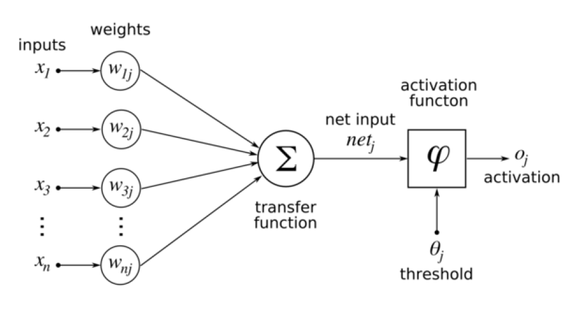

```python
from IPython.display import Image
Image("ann1.png")
```

In the below example (which is simplified with one attribute input $In_1$ and one weight $W_1$, where $Z_1$ is the transfer function, and $A_1$ is the activation function. In this example we are using the sigmoid function (as used in Logistic Regression).

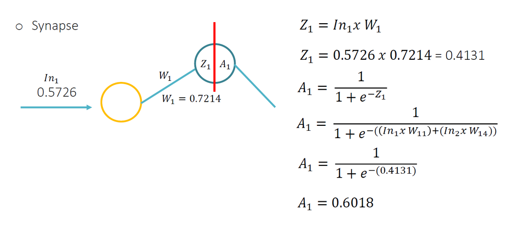

```python
from IPython.display import Image
Image("ann2.png")
```

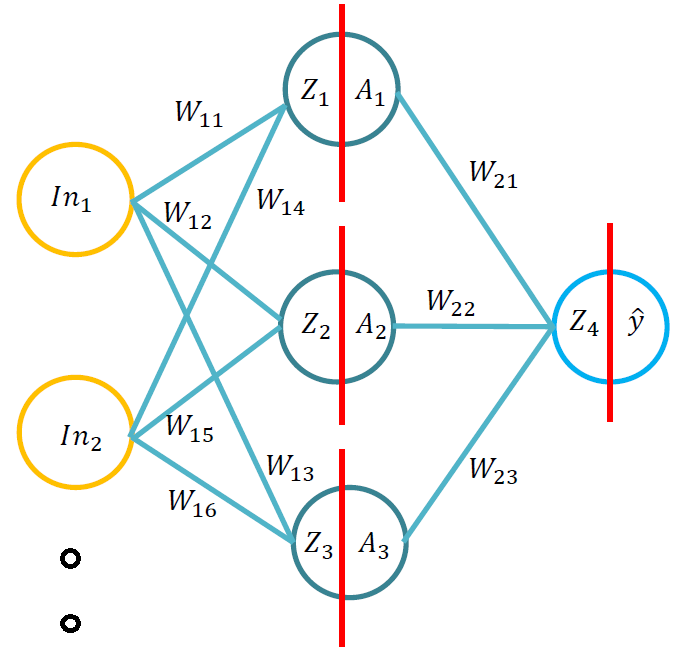

```python
from IPython.display import Image
Image("ann3.png")
```

### Neural Network Learning

Essentially, all that is changed is the weights (altough there are several hyperperameters that help with the learning process), and just like in Linear Regression and Logistic Regression, gradient descent is used, to find the optimum weights. The weihgts are selected as random values, and then iteratively changed using gradient descent to find a heuristic solution.

```python
from IPython.display import Image
Image("gradientDescent.jpg", width = 900, height = 450)
```

[output not shown]

## Deep Learning

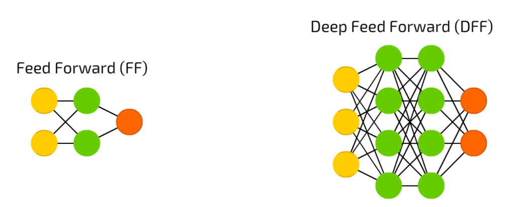

```python
from IPython.display import Image
Image("ann4.png")
```

Deep learning implies multiple hidden layers, and as a result many more synapses, creating a significnat increase in weights. Once the optimal weights are selected, the forward pass, is relatively (computationally) light to compute and can be implimented in JavaScript in a web browser for example.

```
Train on 14 samples
```

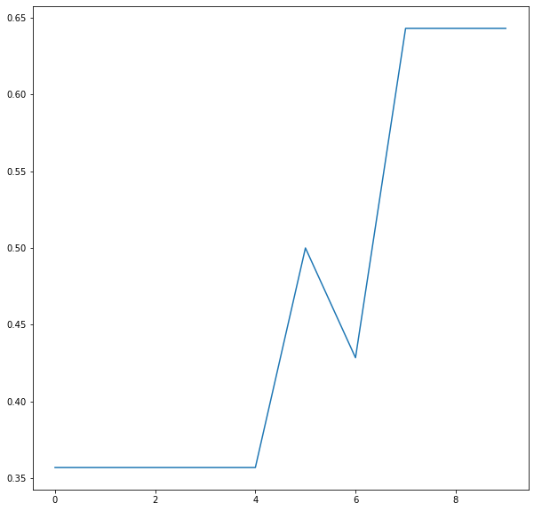

```
[0.50338334]

[0.5028324]


Play
Play
```

```python
# fix random seed for reproducibility
seed = 1
np.random.seed(seed)
tf.random.set_seed(seed)


model = Sequential()
model.add(Dense(10, input_dim=4, activation='sigmoid'))
model.add(Dense(10, activation='sigmoid'))
model.add(Dense(10, activation='sigmoid'))
model.add(Dense(1, activation='sigmoid'))
model.compile(loss='mean_absolute_error', optimizer='sgd',metrics=['acc'])           # Note not correct loss function

results = model.fit(attributes, classValues, epochs=10)
plt.plot(results.history["acc"])
plt.show()



print()
unsceen1 = [[2,1,0,1]]
result1 = model.predict(unsceen1)
print(result1[0])

print()
unsceen2 = [[0,1,0,1]]
result2 = model.predict(unsceen2)
print(result2[0])


# for humans!
print()
print()
if result1[0] < 0.5:
    print("Do not play")
else:
    print("Play")


if result2[0] < 0.5:
    print("Do not play")
else:
    print("Play")
```

```python
print(model.summary())
```

```
Model: "sequential_1"
_________________________________________________________________
Layer (type)                 Output Shape              Param #
=================================================================
dense_2 (Dense)              (None, 10)                50
_________________________________________________________________
dense_3 (Dense)              (None, 10)                110
_________________________________________________________________
dense_4 (Dense)              (None, 10)                110
_________________________________________________________________
dense_5 (Dense)              (None, 1)                 11
=================================================================
Total params: 281
Trainable params: 281
Non-trainable params: 0
_________________________________________________________________
None
```